# Assignment 7

Kai Lukowiak

2018-03-14

# Problem 1

Let $X_1, X_2,...,X_n$ be $n$ mutually independent random variables, each of which is uniformly distributed on the integers from $1$ to $k$. Let $Y$ denote the minimum of the $X_i$’s. Find the distribution of $Y$.

## Solution 1:

Let $\alpha$ be minimum value of $X_i$. The probability of $\alpha$ for any number is given by the total number of possibilities $k^n$ minus the number of possibilities that a number greater than or less than $\alpha$.

More generally:

- Let the total number of posibilities be: $k^n$
- Let the number greater than $\alpha$ be: $(k - \alpha + 1)^n$
- Let the number of less than $\alpha$ be: $(k - \alpha)$

To simulate this:

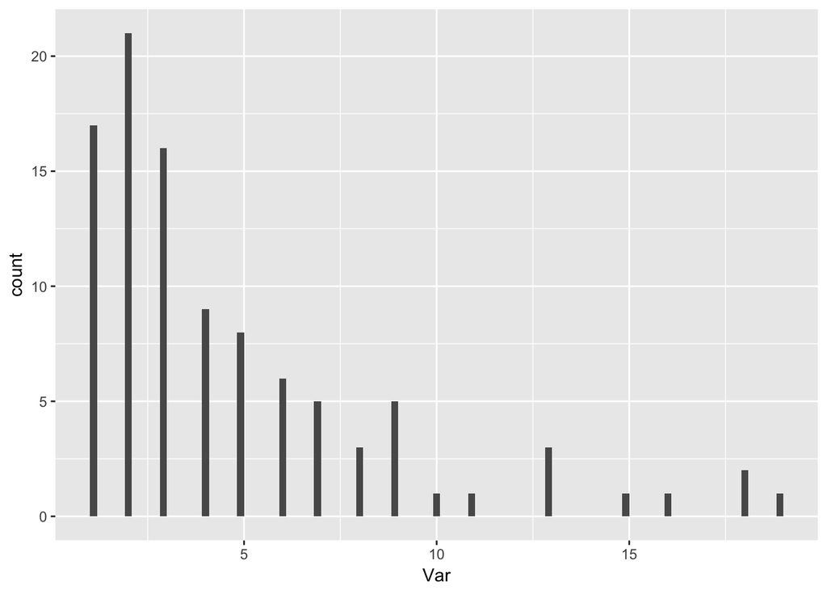

```r
minDist <- function(k,n) {
  Y = c()
  for (i in 1:n){
    X <- sample.int(n, k, replace = TRUE)
    Y[i] = min(X)
  }
  return(Y)
}

Var <- minDist(20, 100)
library(ggplot2)
qplot(Var, geom = 'histogram', bins = 100)
```

# Problem 2

Your organization owns a copier (future lawyers, etc.) or MRI (future doctors). This machine has a manufacturer’s expected lifetime of 10 years. This means that we expect one failure every ten years. (Include the probability statements and R Code for each part.).

## a)

What is the probability that the machine will fail after 8 years?. Provide also the expected value and standard deviation. Model as a geometric. (Hint: the probability is equivalent to not failing during the first 8 years..)

We use the `pgeom` function in R to calculate the proability that it will fail after 8 years given the 0.1 failure rate:

```r
pgeom(7, 0.1, lower.tail = FALSE)
```

```
## [1] 0.4304672
```

## b)

What is the probability that the machine will fail after 8 years?. Provide also the expected value and standard deviation. Model as an exponential.

```r
pexp(8, 0.1, lower.tail = FALSE)
```

```
## [1] 0.449329
```

## c)

What is the probability that the machine will fail after 8 years?. Provide also the expected value and standard deviation. Model as a binomial. (Hint: 0 success in 8 years)

```r
pbinom(0, 8, 0.1)
```

```
## [1] 0.4304672
```

## d)

What is the probability that the machine will fail after 8 years?. Provide also the expected value and standard deviation. Model as a Poisson.

```r
ppois(0, 8/10)
```

```
## [1] 0.449329
```